# Exam 1

## Exam 1

#### Metainformation

1. | Tag | Value |
   | --- | --- |
   | `file` | Descriptive-statistics_vufsw-histogram-0013-nl_vufsw-histogram-0013-nl |
   | `name` | vufsw-histogram-0013-nl |
   | `section` | descriptive statistics/data representation/graphs/histogram |
   | `type` | schoice |
   | `solution` | TRUE, FALSE, FALSE, FALSE |
   | `ID` | 72694 |
   | `Type` | conceptual |
   | `Program` | NA |
   | `Language` | Dutch |
   | `Level` | statistical literacy |

#### Question

   Hieronder is de verdeling weergeven van het geluksniveau van een willekeurige steekproef van 1919 Nederlanders (bron: European Social Survey, 2014). De respondenten kregen de volgende vraag voorgelegd: “Alles bij elkaar genomen, hoe gelukkig zou u zeggen dat u bent?”, waarbij de antwoordmogelijkheden lagen tussen “zeer ongelukkig” (0) en “zeer gelukkig (10). Is deze verdeling rechts-scheef of links-scheef verdeeld? En hoe verhoudt het gemiddelde geluksniveau zich tot de modus en de mediaan?

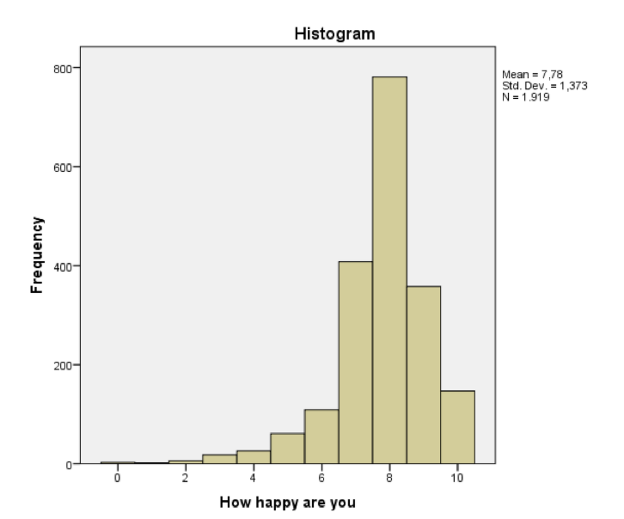

   1. **TRUE:** De verdeling is links-scheef. Het gemiddelde geluksniveau is lager dan de modus en lager dan de mediaan.
   2. **FALSE:** De verdeling is links-scheef. Het gemiddelde geluksniveau is lager dan de modus, maar hoger dan de mediaan.
   3. **FALSE:** De verdeling is rechts-scheef. Het gemiddelde geluksniveau is lager dan de modus, maar hoger dan de mediaan.
   4. **FALSE:** De verdeling is rechts-scheef. Het gemiddelde geluksniveau is lager dan de modus en lager dan de mediaan.

#### Solution

   Language  
   Nederlands

   M&T Basics of quantitative research  
   Basics of quantitative research

   M&T BIS  
   Default value
   1. True
   2. False
   3. False
   4. False